# TakeHomeMidterm

Vikas Sanil

Due 3/11 11:59 pm

*>> Do not distribute outside of ITMD/ITMS/STAT 514, SPRING 2022, Illinois Tech. <<*

# Instructions & Rules

Use this Markdown document as your working copy of the exam, and edit it. Please use output option `pdf_document` or `html_document`.

- *Questions and Points*

This test has **FOUR** questions. Attempt them all. The maximum number of points is **45**.

- *Some standard writing considerations:*
  - Replace comments that instruct you to put code with your own code.
  - Ensure your plots and output are visible and readable.
  - Ensure you’ve typed up an explanation of your answers wherever required.
- *Format*: delete comments and replace with your answers and code. Do not just place code, execute it, and expect the reader to be able to interpret the answer for themselves. Type a sentence saying what you just computed and what the reader should understand.
- *Name*: do not forget to put your name on the exam under the ‘author’ heading.
- *Submission*: your submission must consist of your copy of this Markdown document *and* a knitted `pdf` file (or save a knitted `html` as a `pdf`). Any other type of submission will receive no credit and no opportunity for a re-submission. Late submissions are not accepted.

### Honor code

> I will not give or receive information to or from any other persons during this midterm. This document was edited and PDF knitted by me alone.

*[Vikas Sanil]*

# Getting started

Load the packages you will need for your code to run. Probably you need at least these two, but add others if needed.

*(These were used on previous homework assignments, so you should not have to run the command `install.packages("....")`, but do run that first if `library` does not load.)*

```r
# library("ggplot2")
library("tidyverse") # includes tibbles, ggplot2, dyplr, and more.
```

```r
options(scipen=2)
```

# Obtaining and Understanding the Data

For this exam, we will be using the cybersecurity breach report data downloaded 2015-02-26 from the US Health and Human Services.

To understand what the data represents, here is some information from the *Office for Civil Rights* of the *U.S. Department of Health and Human Services*:

- “As required by section 13402(e)(4) of the HITECH Act, the Secretary must post a list of breaches of unsecured protected health information affecting 500 or more individuals.
- “Since October 2009 organizations in the U.S. that store data on human health are required to report any incident that compromises the confidentiality of 500 or more patients / human subjects (45 C.F.R. 164.408). These reports are publicly available. Our data set was downloaded from the Office for Civil Rights of the U.S. Department of Health and Human Services, 2015-02-26.”

Load this data set and save it as `cyberData`, using the following code:

```r
cyberData<-read.csv(url("https://vincentarelbundock.github.io/Rdatasets/csv/Ecdat/HHSCyberSecurityBreaches.csv"))
```

## Data Exploration

### Question 1. (5 points)

Check the structure of the data using the `str` command. What type of object is `cyberData`? How many observations are recorded? How many variables are recorded? List all of the types of random variables that are recorded based on the output (i.e. int/float etc.).

```r
str(cyberData)
```

```
## 'data.frame':    1151 obs. of  10 variables:
##  $ X                               : int  1 2 3 4 5 6 7 8 9 10 ...
##  $ Name.of.Covered.Entity          : chr  "Brooke Army Medical Center" "Mid America Kidney Stone Association, LLC" "Alaska Department of Health and Social Services" "Health Services for Children with Special Needs, Inc." ...
##  $ State                           : chr  "TX" "MO" "AK" "DC" ...
##  $ Covered.Entity.Type             : chr  "Healthcare Provider" "Healthcare Provider" "Healthcare Provider" "Health Plan" ...
##  $ Individuals.Affected            : int  1000 1000 501 3800 5257 857 6145 952 5166 5900 ...
##  $ Breach.Submission.Date          : chr  "2009-10-21" "2009-10-28" "2009-10-30" "2009-11-17" ...
##  $ Type.of.Breach                  : chr  "Theft" "Theft" "Theft" "Loss" ...
##  $ Location.of.Breached.Information: chr  "Paper/Films" "Network Server" "Other, Other Portable Electronic Device" "Laptop" ...
##  $ Business.Associate.Present      : logi  FALSE FALSE FALSE FALSE FALSE FALSE ...
##  $ Web.Description                 : chr  "A binder containing the protected health information (PHI) of up to 1,272 individuals was stolen from a staff m"| __truncated__ "Five desktop computers containing unencrypted electronic protected health information (e-PHI) were stolen from "| __truncated…
```

> The data set is stored as a data.frame with 1151 rows and 10 columns. There are 1151 observations of 10 variables. All of the types of random variables are integer, character and logical.

### Question 2. (20 points)

Let us compare the number of affected individuals across some states.

- Extract the subset of the data for Kansas and Arkansas; in other words, the subset of the data for which `State` column equals `"KS"` or`"AR"`. Add a third state to the dataframe, say, Illinois (i.e., where `State == "IL"`). Name the new **dataframe** `threeStates`.

```r
cyberData_StateKSnAR<-data.frame(cyberData[cyberData$State=="KS"|cyberData$State=="AR",])
str(cyberData_StateKSnAR)
```

```
## 'data.frame':    14 obs. of  10 variables:
##  $ X                               : int  90 159 178 341 372 389 414 473 588 694 ...
##  $ Name.of.Covered.Entity          : chr  "Occupational Health Partners" "Matthew H. Conrad, M.D., P.A." "University of Arkansas for Medical Sciences" "NEA Baptist Clinic" ...
##  $ State                           : chr  "KS" "KS" "AR" "AR" ...
##  $ Covered.Entity.Type             : chr  "Healthcare Provider" "Healthcare Provider" "Healthcare Provider" "Healthcare Provider" ...
##  $ Individuals.Affected            : int  1105 1200 1000 3116 1472 8275 7757 7121 2863 1900 ...
##  $ Breach.Submission.Date          : chr  "2010-06-01" "2010-09-19" "2010-10-18" "2011-09-07" ...
##  $ Type.of.Breach                  : chr  "Theft" "Theft" "Theft" "Hacking/IT Incident" ...
##  $ Location.of.Breached.Information: chr  "Laptop" "Laptop, Paper/Films" "Other, Other Portable Electronic Device" "Network Server" ...
##  $ Business.Associate.Present      : logi  FALSE FALSE FALSE FALSE FALSE TRUE ...
##  $ Web.Description                 : chr  "\\N" "\\N" "\\N" "\\N" ...
```

```r
cyberData_StateIL<-data.frame(cyberData[cyberData$State=="IL",])
threeStates<-rbind(cyberData_StateKSnAR,cyberData_StateIL)
str(threeStates)
```

```
## 'data.frame':    71 obs. of  10 variables:
##  $ X                               : int  90 159 178 341 372 389 414 473 588 694 ...
##  $ Name.of.Covered.Entity          : chr  "Occupational Health Partners" "Matthew H. Conrad, M.D., P.A." "University of Arkansas for Medical Sciences" "NEA Baptist Clinic" ...
##  $ State                           : chr  "KS" "KS" "AR" "AR" ...
##  $ Covered.Entity.Type             : chr  "Healthcare Provider" "Healthcare Provider" "Healthcare Provider" "Healthcare Provider" ...
##  $ Individuals.Affected            : int  1105 1200 1000 3116 1472 8275 7757 7121 2863 1900 ...
##  $ Breach.Submission.Date          : chr  "2010-06-01" "2010-09-19" "2010-10-18" "2011-09-07" ...
##  $ Type.of.Breach                  : chr  "Theft" "Theft" "Theft" "Hacking/IT Incident" ...
##  $ Location.of.Breached.Information: chr  "Laptop" "Laptop, Paper/Films" "Other, Other Portable Electronic Device" "Network Server" ...
##  $ Business.Associate.Present      : logi  FALSE FALSE FALSE FALSE FALSE TRUE ...
##  $ Web.Description                 : chr  "\\N" "\\N" "\\N" "\\N" ...
```

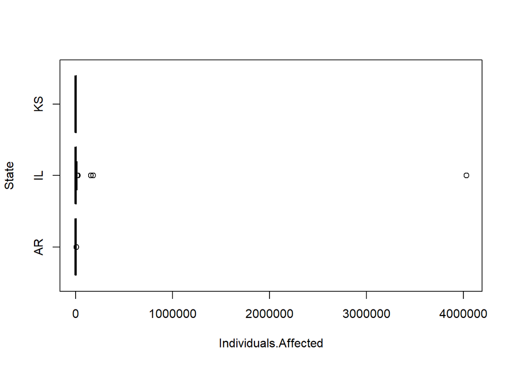

```r
boxplot(Individuals.Affected ~ State, data=threeStates, horizontal = TRUE )
```

The above plot should leave you wondering if Illinois is special, in that it contains some really large data breaches. Let’s investigate:

- How many observations in `cyberData` represent a cyber security breach that affected 100,000 individuals or more?

```r
str(cyberData[cyberData$Individuals.Affected >=100000,])
```

```
## 'data.frame':    40 obs. of  10 variables:
##  $ X                               : int  62 75 91 93 112 115 180 182 185 216 ...
##  $ Name.of.Covered.Entity          : chr  "Affinity Health Plan, Inc." "Millennium Medical Management Resources, Inc." "AvMed, Inc." "Siemens Medical Solutions, USA, Inc" ...
##  $ State                           : chr  "NY" "IL" "FL" "PA" ...
##  $ Covered.Entity.Type             : chr  "Health Plan" "Business Associate" "Health Plan" "Business Associate" ...
##  $ Individuals.Affected            : int  344579 180111 1220000 130495 105470 800000 1023209 475000 115000 156000 ...
##  $ Breach.Submission.Date          : chr  "2010-04-14" "2010-04-29" "2010-06-03" "2010-06-04" ...
##  $ Type.of.Breach                  : chr  "Theft" "Theft" "Theft" "Theft" ...
##  $ Location.of.Breached.Information: chr  "Other" "Other, Other Portable Electronic Device" "Laptop" "Other" ...
##  $ Business.Associate.Present      : logi  FALSE TRUE FALSE TRUE TRUE TRUE ...
##  $ Web.Description                 : chr  "Under a settlement with the U.S. Department of Health and Human Services (HHS), Affinity Health Plan, Inc. will"| __truncated__ "\\N" "Two laptop computers with questionable encryption (each containing the electronic protected health information "| __tru…
```

```r
str(cyberData_StateIL[cyberData_StateIL$Individuals.Affected >=100000,])
```

```
## 'data.frame':    3 obs. of  10 variables:
##  $ X                               : int  75 746 1126
##  $ Name.of.Covered.Entity          : chr  "Millennium Medical Management Resources, Inc." "Advocate Health and Hospitals Corporation, d/b/a Advocate Medical Group" "Walgreen Co."
##  $ State                           : chr  "IL" "IL" "IL"
##  $ Covered.Entity.Type             : chr  "Business Associate" "Healthcare Provider" "Healthcare Provider"
##  $ Individuals.Affected            : int  180111 4029530 160000
##  $ Breach.Submission.Date          : chr  "2010-04-29" "2013-08-23" "2014-12-15"
##  $ Type.of.Breach                  : chr  "Theft" "Theft" "Other"
##  $ Location.of.Breached.Information: chr  "Other, Other Portable Electronic Device" "Desktop Computer" "Paper/Films"
##  $ Business.Associate.Present      : logi  TRUE FALSE FALSE
##  $ Web.Description                 : chr  "\\N" "\\N" "\\N"
```

## Small analyses across time

Let us now compare attacks before and after 2013. The goal is to see if there is a significant difference in mean number of affected individuals.

### Question 3. (10 points)

Check the type of the `Breach.Submission.Date` column: is it a numeric? What type is it?

```r
typeof(cyberData$Breach.Submission.Date)
```

```
## [1] "character"
```

Let us change it to a numeric and extract *the year only*. The code that does this is `as.numeric(format(as.Date(.....),"%Y"))`. Let us use this code to break up the data to before and after 2013, like this:

```r
before2013 <- subset(cyberData, as.numeric(format(as.Date(Breach.Submission.Date),"%Y")) <=2013 )
after2013  <- subset(cyberData, as.numeric(format(as.Date(Breach.Submission.Date),"%Y")) > 2013 )
```

How many observations are in each subset of the population?

> Number of observation in breach before 2013 848. Number of observation in breach after 2013 303.

## Specific type of security breaches

### Question 4. (10 points)

- What proportion of data entries in `cyberData` have `Type.of.Breach == "Hacking/IT Incident"` ?

```r
nrow(cyberData[cyberData$Type.of.Breach== "Hacking/IT Incident",])
```

```
## [1] 77
```

```r
nrow(before2013[before2013$Type.of.Breach== "Hacking/IT Incident",])
```

```
## [1] 49
```

```r
nrow(after2013[after2013$Type.of.Breach== "Hacking/IT Incident",])
```

```
## [1] 28
```

# End of midterm, congratulations!

*>> Do not distribute outside of ITMD/ITMS/STAT 514, SPRING 2022, Illinois Tech. <<*